# Statistical Evaluation : Sample Size and Power Calculations for Tests Comparing Means in Clinical Research

## 1.3 Multiple-Sample Design One-Way ANOVA Pairwise (MSDOWAP)

[Multiple-Sample Design One-Way ANOVA Pairwise](https://www.taylorfrancis.com/books/mono/10.1201/9781315183084/sample-size-calculations-clinical-research-shein-chung-chow-jun-shao-hansheng-wang-yuliya-lokhnygina) involves individual numeric response values from sampled subjects across three or more competing treatment groups. In clinical research, responses could be between multiple test drugs and a placebo control or an active control agent; or between multiple competing agents. The response and treatment variables are modeled using a One-Way ANOVA model involving the fixed effect of the treatment and random errors which are assumed to be independent and identically distributed normal random variables with zero mean and a given variance. For a pairwise comparison between treatments, all possible combinations must be analyzed. Due to the multiple comparisons inflating the Type I error, adjustments arre made for controlling the overall Type I error rate at the desired significance level. Parameters needed for the computations are as follows:  
**[A]** Mean Treatment 1 Response : True mean response value obtained from sampled subjects in the first treatment group  
**[B]** Mean Treatment 2 Response : True mean response value obtained from sampled subjects in the second treatment group  
**[C]** Epsilon : Mean response differences between the two treatment groups  
**[D]** Standard Deviation : Data variability based from the from sampled subjects from both treatment groups  
**[E]** Alpha : Maximum allowed Type I error  
**[F]** Beta : Maximum allowed Type II error  
**[G]** Tau : Number of treatment groups  
A case scenario was provided as follows to demonstrate sample size computation and power analysis as applied on different treatment pairs:  
**[Case Scenario]** A clinical research study was conducted to investigate pharmaceutical compounds for treatment of patients with cancer. The investigator is not only interested in showing efficacy of the test drug but also in establishing the dose response curve. To achieve this study objective, a three-arm parallel group, double-blind, randomized clinical trial was designed to compare three treatments: A (Placebo), B (10 mg) and C (30 mg). Based on the results from the pilot study, it is estimated that the standard deviation is 3.5.

### 1.3.1 Test for Equality (MSDOWAP_EQUALITY)

**[Research Question]** Suppose that the hypothesized mean clinical response for the placebo treatment is 9.0. However, clinical responses for Treatments B and C were expected to range from 11.0 to 13.0 and 15.0 to 17.0, respectively, with increments of 0.5. The study aims to demonstrate the efficacy of each treatment as pairwise compared against each other. Given a level of significance of 0.05, evaluate the sample size range for a test of equality to achieve statistical test powers equal to 70%, 80% and 90%.  
**[Null Hypothesis]** Mean clinical response of the first evaluated treatment equals the Mean clinical response of the second evaluated treatment  
**[Alternative Hypothesis]** Mean clinical response of the first evaluated treatment is not equal to the Mean clinical response of the second evaluated treatment  
**[Hypothesis Test]** Rejection of the null hypothesis implies difference between the mean clinical response values between both evaluated treatments  
**[A]** Mean Response : Treatment A : 9.0  
**[B]** Mean Response : Treatment B : 11.0 to 13.0 at 0.5 intervals  
**[C]** Mean Response : Treatment C : 15.0 to 17.0 at 0.5 intervals  
**[D]** Standard Deviation : 3.50  
**[E]** Alpha : 0.05  
**[F]** Beta : 0.30, 0.20 and 0.10 corresponding to 70%, 80% and 90% statistical powers  
**[G]** Tau : 3 representing the number of treatments

**Code Chunk | Output**

```r
##################################
# Defining a fixed hypothesized value for mu_A
##################################
mu_AF=9.0

##################################
# Defining a range of hypothesized values for mu_B
##################################
mu_BR=seq(11.0,13.0,0.5)
##################################
# Defining a fixed hypothesized value for mu_B
# using the highest value from the range
##################################
mu_BF=13.0

##################################
# Defining a range of hypothesized value for mu_C
##################################
mu_CR=seq(15.0,17.0,0.5)

##################################
# Defining a fixed hypothesized value for the standard deviation
##################################
sd=3.5

##################################
# Defining a fixed hypothesized value for the Type I error
##################################
alpha=0.05

##################################
# Defining a range of possible hypothesized values for the Type II error
##################################
beta=c(0.30,0.20,0.10)

##################################
# Defining the number of treatments
##################################
tau=3

##################################
# Conducting a pairwise comparison
# between Treatments A and B
##################################

##################################
# Computing the range of samples sizes based on different levels of Type II errors
##################################
beta_1=beta[1]
(n_Beta30=2*(sd*(qnorm(1-alpha/(2/tau))+qnorm(1-beta_1))/(mu_BR-mu_AF))^2)
```

```
## [1] 23.624302 15.119553 10.499690  7.714058  5.906075
```

```r
ceiling(n_Beta30)
```

```
## [1] 24 16 11  8  6
```

```r
z_Beta30=(mu_BR-mu_AF)/(sd*sqrt(2/n_Beta30))
(Power_Beta30=pnorm(z_Beta30-qnorm(1-alpha/(2/tau)))+pnorm(-z_Beta30-qnorm(1-alpha/(2/tau))))
```

```
## [1] 0.7003327 0.7003327 0.7003327 0.7003327 0.7003327
```

```r
beta_2=beta[2]
(n_Beta20=2*(sd*(qnorm(1-alpha/(2/tau))+qnorm(1-beta_2))/(mu_BR-mu_AF))^2)
```

```
## [1] 31.872403 20.398338 14.165513 10.407315  7.968101
```

```r
ceiling(n_Beta20)
```

```
## [1] 32 21 15 11  8
```

```r
z_Beta20=(mu_BR-mu_AF)/(sd*sqrt(2/n_Beta20))
(Power_Beta20=pnorm(z_Beta20-qnorm(1-alpha/(2/tau)))+pnorm(-z_Beta20-qnorm(1-alpha/(2/tau))))
```

```
## [1] 0.8000993 0.8000993 0.8000993 0.8000993 0.8000993
```

```r
beta_3=beta[3]
(n_Beta10=2*(sd*(qnorm(1-alpha/(2/tau))+qnorm(1-beta_3))/(mu_BR-mu_AF))^2)
```

```
## [1] 45.35129 29.02483 20.15613 14.80859 11.33782
```

```r
ceiling(n_Beta10)
```

```
## [1] 46 30 21 15 12
```

```r
z_Beta10=(mu_BR-mu_AF)/(sd*sqrt(2/n_Beta10))
(Power_Beta10=pnorm(z_Beta10-qnorm(1-alpha/(2/tau)))+pnorm(-z_Beta10-qnorm(1-alpha/(2/tau))))
```

```
## [1] 0.9000159 0.9000159 0.9000159 0.9000159 0.9000159
```

```r
MultipleSampleDesign.AB.Equality <- as.data.frame(cbind(mu_BR,n_Beta30,n_Beta20,n_Beta10))
names(MultipleSampleDesign.AB.Equality) <- c("Clinical.Response",
                                 "Power=70%",
                                 "Power=80%",
                                 "Power=90%")

##################################
# Restructuring the data
##################################
MultipleSampleDesign.AB.Equality.Reshaped <- gather(MultipleSampleDesign.AB.Equality,
                                            "Power=70%","Power=80%","Power=90%",
                                            key="Power",
                                            value="Sample.Size")
MultipleSampleDesign.AB.Equality.Reshaped$Label <- rep("MSDOWAP_AB_EQUALITY",nrow(MultipleSampleDesign.AB.Equality.Reshaped))

MultipleSampleDesign.AB.Equality.Reshaped
```

```
##    Clinical.Response     Power Sample.Size               Label
## 1               11.0 Power=70%   23.624302 MSDOWAP_AB_EQUALITY
## 2               11.5 Power=70%   15.119553 MSDOWAP_AB_EQUALITY
## 3               12.0 Power=70%   10.499690 MSDOWAP_AB_EQUALITY
## 4               12.5 Power=70%    7.714058 MSDOWAP_AB_EQUALITY
## 5               13.0 Power=70%    5.906075 MSDOWAP_AB_EQUALITY
## 6               11.0 Power=80%   31.872403 MSDOWAP_AB_EQUALITY
## 7               11.5 Power=80%   20.398338 MSDOWAP_AB_EQUALITY
## 8               12.0 Power=80%   14.165513 MSDOWAP_AB_EQUALITY
## 9               12.5 Power=80%   10.407315 MSDOWAP_AB_EQUALITY
## 10              13.0 Power=80%    7.968101 MSDOWAP_AB_EQUALITY
## 11              11.0 Power=90%   45.351294 MSDOWAP_AB_EQUALITY
## 12              11.5 Power=90%   29.024828 MSDOWAP_AB_EQUALITY
## 13              12.0 Power=90%   20.156131 MSDOWAP_AB_EQUALITY
## 14              12.5 Power=90%   14.808586 MSDOWAP_AB_EQUALITY
## 15              13.0 Power=90%   11.337823 MSDOWAP_AB_EQUALITY
```

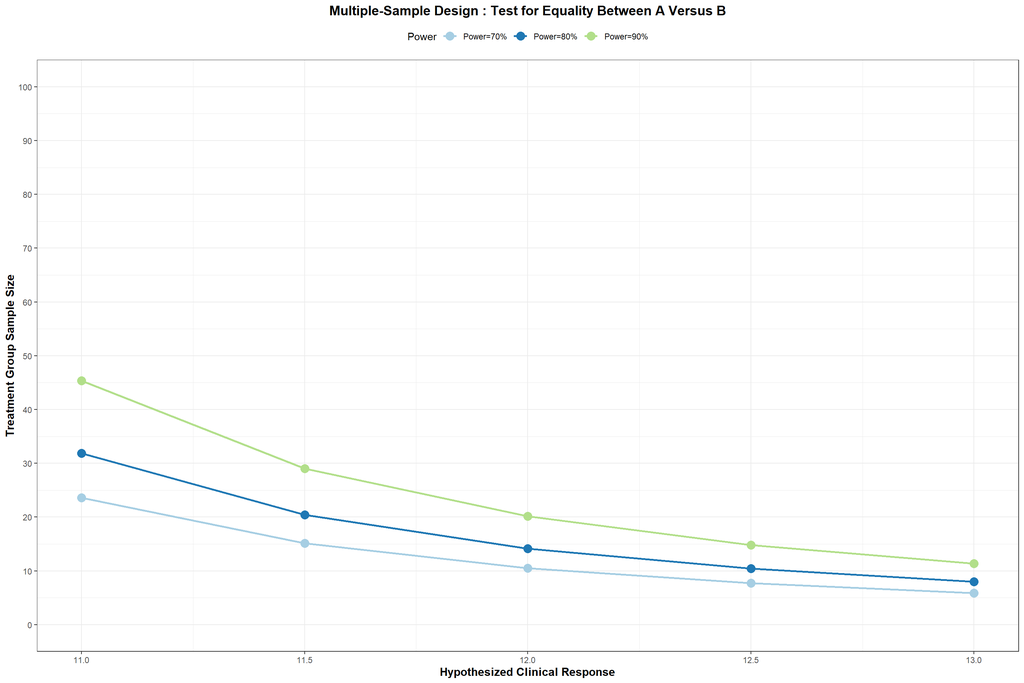

```r
##################################
# Plotting the sample sizes and power curves
##################################
(MultipleSampleDesign.AB.Equality.PowerAnalysis <-    ggplot(MultipleSampleDesign.AB.Equality.Reshaped,
                                                      aes(x=Clinical.Response,
                                                          y=Sample.Size,
                                                          color=Power)) +
   geom_line(size=1)+
   geom_point(size=4)+
   theme_bw() +
   scale_color_brewer(palette="Paired") +
   scale_x_continuous(name="Hypothesized Clinical Response",
                      limits=c(11,13),
                      breaks=seq(11,13,by=0.5)) +
  scale_y_continuous(name="Treatment Group Sample Size",
                     limits=c(0,100),
                     breaks=seq(0,100,by=10)) +
  theme(axis.title.x=element_text(color="black",face="bold",size=12),
        legend.position="top",
        axis.title.y=element_text(color="black",face="bold",size=12),
        plot.title=element_text(color="black",size=14,face="bold",hjust=0.50)) +
  ggtitle("Multiple-Sample Design : Test for Equality Between A Versus B"))
```

```r
##################################
# Conducting a pairwise comparison
# between Treatments A and C
##################################

##################################
# Computing the range of samples sizes based on different levels of Type II errors
##################################
beta_1=beta[1]
(n_Beta30=2*(sd*(qnorm(1-alpha/(2/tau))+qnorm(1-beta_1))/(mu_CR-mu_AF))^2)
```

```
## [1] 2.624922 2.236620 1.928514 1.679950 1.476519
```

```r
ceiling(n_Beta30)
```

```
## [1] 3 3 2 2 2
```

```r
z_Beta30=(mu_CR-mu_AF)/(sd*sqrt(2/n_Beta30))
(Power_Beta30=pnorm(z_Beta30-qnorm(1-alpha/(2/tau)))+pnorm(-z_Beta30-qnorm(1-alpha/(2/tau))))
```

```
## [1] 0.7003327 0.7003327 0.7003327 0.7003327 0.7003327
```

```r
beta_2=beta[2]
(n_Beta20=2*(sd*(qnorm(1-alpha/(2/tau))+qnorm(1-beta_2))/(mu_CR-mu_AF))^2)
```

```
## [1] 3.541378 3.017506 2.601829 2.266482 1.992025
```

```r
ceiling(n_Beta20)
```

```
## [1] 4 4 3 3 2
```

```r
z_Beta20=(mu_CR-mu_AF)/(sd*sqrt(2/n_Beta20))
(Power_Beta20=pnorm(z_Beta20-qnorm(1-alpha/(2/tau)))+pnorm(-z_Beta20-qnorm(1-alpha/(2/tau))))
```

```
## [1] 0.8000993 0.8000993 0.8000993 0.8000993 0.8000993
```

```r
beta_3=beta[3]
(n_Beta10=2*(sd*(qnorm(1-alpha/(2/tau))+qnorm(1-beta_3))/(mu_CR-mu_AF))^2)
```

```
## [1] 5.039033 4.293614 3.702146 3.224981 2.834456
```

```r
ceiling(n_Beta10)
```

```
## [1] 6 5 4 4 3
```

```r
z_Beta10=(mu_CR-mu_AF)/(sd*sqrt(2/n_Beta10))
(Power_Beta10=pnorm(z_Beta10-qnorm(1-alpha/(2/tau)))+pnorm(-z_Beta10-qnorm(1-alpha/(2/tau))))
```

```
## [1] 0.9000159 0.9000159 0.9000159 0.9000159 0.9000159
```

```r
MultipleSampleDesign.AC.Equality <- as.data.frame(cbind(mu_CR,n_Beta30,n_Beta20,n_Beta10))
names(MultipleSampleDesign.AC.Equality) <- c("Clinical.Response",
                                 "Power=70%",
                                 "Power=80%",
                                 "Power=90%")

##################################
# Restructuring the data
##################################
MultipleSampleDesign.AC.Equality.Reshaped <- gather(MultipleSampleDesign.AC.Equality,
                                            "Power=70%","Power=80%","Power=90%",
                                            key="Power",
                                            value="Sample.Size")
MultipleSampleDesign.AC.Equality.Reshaped$Label <- rep("MSDOWAP_AC_EQUALITY",nrow(MultipleSampleDesign.AC.Equality.Reshaped))

MultipleSampleDesign.AC.Equality.Reshaped
```

```
##    Clinical.Response     Power Sample.Size               Label
## 1               15.0 Power=70%    2.624922 MSDOWAP_AC_EQUALITY
## 2               15.5 Power=70%    2.236620 MSDOWAP_AC_EQUALITY
## 3               16.0 Power=70%    1.928514 MSDOWAP_AC_EQUALITY
## 4               16.5 Power=70%    1.679950 MSDOWAP_AC_EQUALITY
## 5               17.0 Power=70%    1.476519 MSDOWAP_AC_EQUALITY
## 6               15.0 Power=80%    3.541378 MSDOWAP_AC_EQUALITY
## 7               15.5 Power=80%    3.017506 MSDOWAP_AC_EQUALITY
## 8               16.0 Power=80%    2.601829 MSDOWAP_AC_EQUALITY
## 9               16.5 Power=80%    2.266482 MSDOWAP_AC_EQUALITY
## 10              17.0 Power=80%    1.992025 MSDOWAP_AC_EQUALITY
## 11              15.0 Power=90%    5.039033 MSDOWAP_AC_EQUALITY
## 12              15.5 Power=90%    4.293614 MSDOWAP_AC_EQUALITY
## 13              16.0 Power=90%    3.702146 MSDOWAP_AC_EQUALITY
## 14              16.5 Power=90%    3.224981 MSDOWAP_AC_EQUALITY
## 15              17.0 Power=90%    2.834456 MSDOWAP_AC_EQUALITY
```

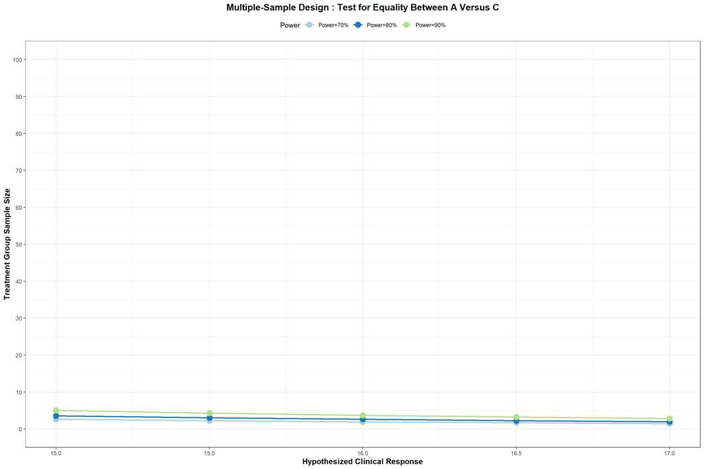

```r
##################################
# Plotting the sample sizes and power curves
##################################
(MultipleSampleDesign.AC.Equality.PowerAnalysis <-    ggplot(MultipleSampleDesign.AC.Equality.Reshaped,
                                                      aes(x=Clinical.Response,
                                                          y=Sample.Size,
                                                          color=Power)) +
   geom_line(size=1)+
   geom_point(size=4)+
   theme_bw() +
   scale_color_brewer(palette="Paired") +
   scale_x_continuous(name="Hypothesized Clinical Response",
                      limits=c(15,17),
                      breaks=seq(15,17,by=0.5)) +
  scale_y_continuous(name="Treatment Group Sample Size",
                     limits=c(0,100),
                     breaks=seq(0,100,by=10)) +
  theme(axis.title.x=element_text(color="black",face="bold",size=12),
        legend.position="top",
        axis.title.y=element_text(color="black",face="bold",size=12),
        plot.title=element_text(color="black",size=14,face="bold",hjust=0.50)) +
  ggtitle("Multiple-Sample Design : Test for Equality Between A Versus C"))
```

```r
##################################
# Conducting a pairwise comparison
# between Treatments B and C
##################################

##################################
# Computing the range of samples sizes based on different levels of Type II errors
##################################
beta_1=beta[1]
(n_Beta30=2*(sd*(qnorm(1-alpha/(2/tau))+qnorm(1-beta_1))/(mu_CR-mu_BF))^2)
```

```
## [1] 23.624302 15.119553 10.499690  7.714058  5.906075
```

```r
ceiling(n_Beta30)
```

```
## [1] 24 16 11  8  6
```

```r
z_Beta30=(mu_CR-mu_BF)/(sd*sqrt(2/n_Beta30))
(Power_Beta30=pnorm(z_Beta30-qnorm(1-alpha/(2/tau)))+pnorm(-z_Beta30-qnorm(1-alpha/(2/tau))))
```

```
## [1] 0.7003327 0.7003327 0.7003327 0.7003327 0.7003327
```

```r
beta_2=beta[2]
(n_Beta20=2*(sd*(qnorm(1-alpha/(2/tau))+qnorm(1-beta_2))/(mu_CR-mu_BF))^2)
```

```
## [1] 31.872403 20.398338 14.165513 10.407315  7.968101
```

```r
ceiling(n_Beta20)
```

```
## [1] 32 21 15 11  8
```

```r
z_Beta20=(mu_CR-mu_BF)/(sd*sqrt(2/n_Beta20))
(Power_Beta20=pnorm(z_Beta20-qnorm(1-alpha/(2/tau)))+pnorm(-z_Beta20-qnorm(1-alpha/(2/tau))))
```

```
## [1] 0.8000993 0.8000993 0.8000993 0.8000993 0.8000993
```

```r
beta_3=beta[3]
(n_Beta10=2*(sd*(qnorm(1-alpha/(2/tau))+qnorm(1-beta_3))/(mu_CR-mu_BF))^2)
```

```
## [1] 45.35129 29.02483 20.15613 14.80859 11.33782
```

```r
ceiling(n_Beta10)
```

```
## [1] 46 30 21 15 12
```

```r
z_Beta10=(mu_CR-mu_BF)/(sd*sqrt(2/n_Beta10))
(Power_Beta10=pnorm(z_Beta10-qnorm(1-alpha/(2/tau)))+pnorm(-z_Beta10-qnorm(1-alpha/(2/tau))))
```

```
## [1] 0.9000159 0.9000159 0.9000159 0.9000159 0.9000159
```

```r
MultipleSampleDesign.BC.Equality <- as.data.frame(cbind(mu_CR,n_Beta30,n_Beta20,n_Beta10))
names(MultipleSampleDesign.BC.Equality) <- c("Clinical.Response",
                                 "Power=70%",
                                 "Power=80%",
                                 "Power=90%")

##################################
# Restructuring the data
##################################
MultipleSampleDesign.BC.Equality.Reshaped <- gather(MultipleSampleDesign.BC.Equality,
                                            "Power=70%","Power=80%","Power=90%",
                                            key="Power",
                                            value="Sample.Size")
MultipleSampleDesign.BC.Equality.Reshaped$Label <- rep("MSDOWAP_BC_EQUALITY",nrow(MultipleSampleDesign.BC.Equality.Reshaped))

MultipleSampleDesign.BC.Equality.Reshaped
```

```
##    Clinical.Response     Power Sample.Size               Label
## 1               15.0 Power=70%   23.624302 MSDOWAP_BC_EQUALITY
## 2               15.5 Power=70%   15.119553 MSDOWAP_BC_EQUALITY
## 3               16.0 Power=70%   10.499690 MSDOWAP_BC_EQUALITY
## 4               16.5 Power=70%    7.714058 MSDOWAP_BC_EQUALITY
## 5               17.0 Power=70%    5.906075 MSDOWAP_BC_EQUALITY
## 6               15.0 Power=80%   31.872403 MSDOWAP_BC_EQUALITY
## 7               15.5 Power=80%   20.398338 MSDOWAP_BC_EQUALITY
## 8               16.0 Power=80%   14.165513 MSDOWAP_BC_EQUALITY
## 9               16.5 Power=80%   10.407315 MSDOWAP_BC_EQUALITY
## 10              17.0 Power=80%    7.968101 MSDOWAP_BC_EQUALITY
## 11              15.0 Power=90%   45.351294 MSDOWAP_BC_EQUALITY
## 12              15.5 Power=90%   29.024828 MSDOWAP_BC_EQUALITY
## 13              16.0 Power=90%   20.156131 MSDOWAP_BC_EQUALITY
## 14              16.5 Power=90%   14.808586 MSDOWAP_BC_EQUALITY
## 15              17.0 Power=90%   11.337823 MSDOWAP_BC_EQUALITY
```

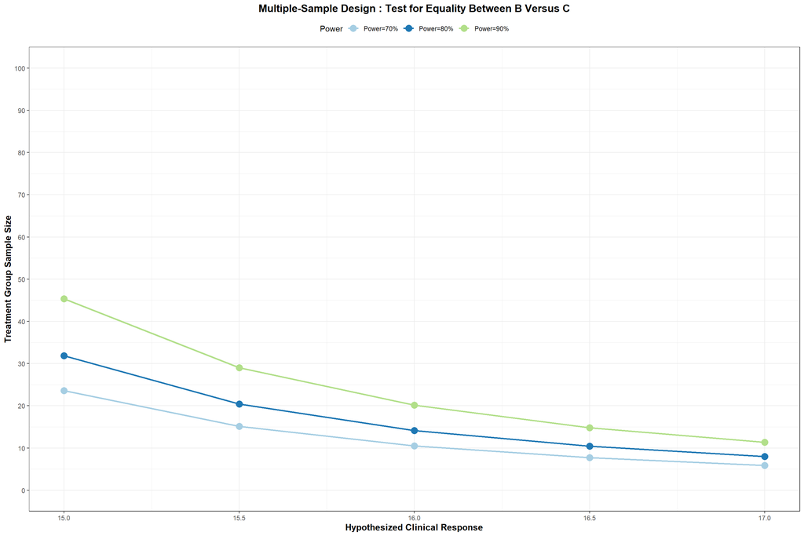

```r
##################################
# Plotting the sample sizes and power curves
##################################
(MultipleSampleDesign.BC.Equality.PowerAnalysis <-    ggplot(MultipleSampleDesign.BC.Equality.Reshaped,
                                                      aes(x=Clinical.Response,
                                                          y=Sample.Size,
                                                          color=Power)) +
   geom_line(size=1)+
   geom_point(size=4)+
   theme_bw() +
   scale_color_brewer(palette="Paired") +
   scale_x_continuous(name="Hypothesized Clinical Response",
                      limits=c(15,17),
                      breaks=seq(15,17,by=0.5)) +
  scale_y_continuous(name="Treatment Group Sample Size",
                     limits=c(0,100),
                     breaks=seq(0,100,by=10)) +
  theme(axis.title.x=element_text(color="black",face="bold",size=12),
        legend.position="top",
        axis.title.y=element_text(color="black",face="bold",size=12),
        plot.title=element_text(color="black",size=14,face="bold",hjust=0.50)) +
  ggtitle("Multiple-Sample Design : Test for Equality Between B Versus C"))
```